# ISYE 6740 - Homework 3

#### Date: 6/20/2021

#### By: Erik Magnusson

## 1. Density estimation: Psychological experiments

Imports

```python
import csv
import numpy as np
import numpy.matlib
import pandas as pd
import scipy.sparse.linalg as ll
import matplotlib.pyplot as plt
from mpl_toolkits.mplot3d import Axes3D
from sklearn import preprocessing
from scipy import stats
import seaborn as sns
```

### 1 (a): 1-dimensional histogram and KDE

```python
df = pd.read_csv('data/n90pol.csv')
data = pd.read_csv('data/n90pol.csv').to_numpy()
y = data[:,2]
data = data[:,:2]

m, n = data.shape

amygdala = data[:,0]
acc = data[:,1]
```

#### 1-dimensional histogram for amygdala

Bins are set to 7 to show the higher density of values at the left portion of the histogram

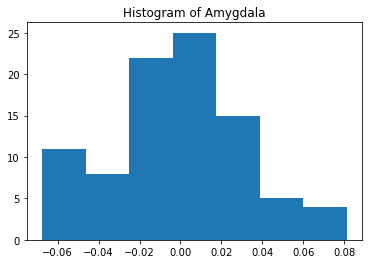

```python
_ = plt.hist(amygdala, bins=7)
plt.title("Histogram of Amygdala")
plt.show()
```

#### 1-dimensional KDE for amygdala

Bandwidth is set to 0.3 to show the smaller density peak at the left of the distribution

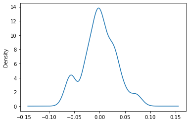

```python
ax = df['amygdala'].plot.kde(bw_method=0.3)
```

#### 1-dimensional histogram for acc

Bins are set to 9 to show the higher density of values at the right portion of the graph

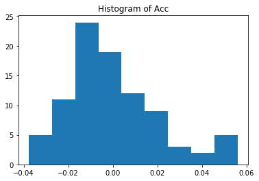

```python
_ = plt.hist(acc, bins=9)
plt.title("Histogram of Acc")
plt.show()
```

#### 1-dimensional KDE for acc

Bandwidth is set to 0.3 to show the smaller density peak at the right of the distribution

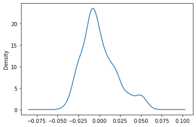

```python
ax = df['acc'].plot.kde(bw_method=0.3)
```

### 1 (b): 2-dimensional histogram

The bin sizes for amygdala and acc are 7 and 9, respectively, because those values show the peak around (-0.01, -0.01).

Additionally, those bins sizes show the smaller amygdala peak around -0.05 and smaller acc peak around 0.05.

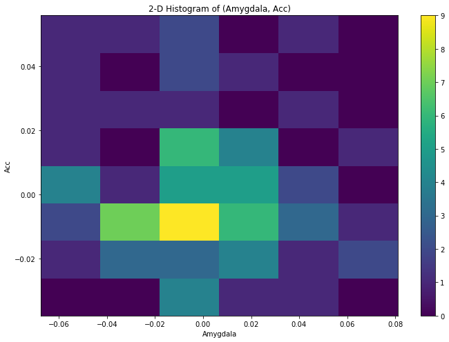

```python
# adapted from: https://www.geeksforgeeks.org/plot-2-d-histogram-in-python-using-matplotlib/
x1 = data[:,0]
x2 = data[:,1]

# Creating bins
x1_min = np.min(x1)
x1_max = np.max(x1)

x2_min = np.min(x2)
x2_max = np.max(x2)

x1_bins = np.linspace(x1_min, x1_max, 7)#7
x2_bins = np.linspace(x2_min, x2_max, 9)#9

fig, ax = plt.subplots(figsize =(10, 7))
# Creating plot
plt.hist2d(x1, x2, bins =[x1_bins, x2_bins])
plt.title("2-D Histogram of (Amygdala, Acc)")

ax.set_xlabel('Amygdala')
ax.set_ylabel('Acc')

plt.colorbar()

# show plot
plt.tight_layout()
plt.show()
```

### 1 (c): 2-dimensional KDE

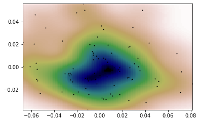

```python
# adapted from : https://docs.scipy.org/doc/scipy/reference/
                    # generated/scipy.stats.gaussian_kde.html
x_1, x_2 = np.mgrid[x1_min:x1_max:100j, x2_min:x2_max:100j]
positions = np.vstack([x_1.ravel(), x_2.ravel()])
values = np.vstack([x1, x2])
kernel = stats.gaussian_kde(values, bw_method=0.45)
Z = np.reshape(kernel(positions).T, x_1.shape)

fig, ax = plt.subplots()
ax.imshow(np.rot90(Z), cmap=plt.cm.gist_earth_r,
          extent=[x1_min, x1_max, x2_min, x2_max])
ax.plot(x1,x2, 'k.', markersize=2)
ax.set_xlim([x1_min, x1_max])
ax.set_ylim([x2_min, x2_max])
plt.show()
```

### 1 (d): Conditional KDEs with Orientation

Estimated conditional distribution of amygdala conditioning on political orientation

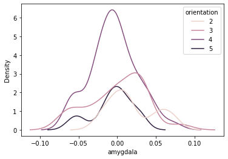

```python
sns.kdeplot(data=df, x="amygdala", hue="orientation", bw_method=0.4)
```

Estimated conditional distribution of acc conditioning on political orientation

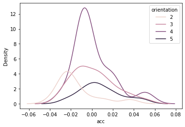

```python
sns.kdeplot(data=df, x="acc", hue="orientation", bw_method=0.4)
```

#### Explanation

Political orientation is ranked from 1 (very conservative) to 5 (very liberal). In the conditional distributions above, one can see that more conservative orientations are associated with smaller acc brain regions and larger amygdala regions. On the other hand, liberal orientations appear to have regular acc and amygdala brain region volumes. A kernel bandwidth of 0.4 was effective when viewing these associations.

Conditional sample means for amygdala and acc

```python
df.groupby('orientation').mean().transpose()
```

| orientation | 2 | 3 | 4 | 5 |
| --- | --- | --- | --- | --- |
| amygdala | 0.019062 | 0.000588 | -0.00472 | -0.005692 |
| acc | -0.014769 | 0.001671 | 0.00131 | 0.008142 |

### 1 (e): Conditional Joint Distribution of the volume of the amygdala and acc

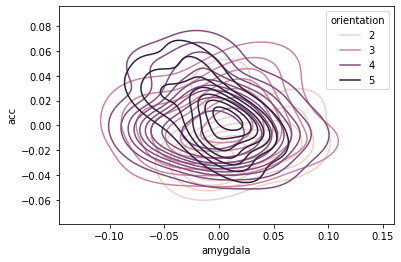

```python
# adapted from: https://seaborn.pydata.org/generated/seaborn.kdeplot.html#seaborn.kdeplot
sns.kdeplot(data=df, x="amygdala", y="acc", hue="orientation", bw_method=0.7)
```

Using a kernel bandwidth of 0.7, I was able to limit the noise in the joint distribution and view the overall associations between orientation and amygdala/acc volumes. The joint distribution above confirms my earlier conclusions when analyzing the conditional distributions for acc and amygdala volumes with orientation. One can see the lighter-colored orientation contours (i.e., those associated with conservative orientations) located among larger amygdala volumes and lower acc volumes than more liberal orientations. Like before, the contours associated with liberal orientations are located more centrally in terms of both acc and amygdala volume.

## 2. Implementing EM for MNIST dataset

Import data (already formatted as 28x28 pixel images in each column (1990 columns))

```python
from scipy.stats import multivariate_normal as mvn
import scipy as sp
import scipy.io
from sklearn import preprocessing
from sklearn.cluster import KMeans
%matplotlib inline
```

```python
mat = scipy.io.loadmat('data/data.mat')
label = scipy.io.loadmat('data/label.mat')
```

```python
x = mat['data'].T.copy() #transform to shape: (1990, 784)
y = label['trueLabel'].copy() # shape: (1, 1990)
```

Data is already scaled to between (0, 1)

```python
print(np.min(x), np.max(x))
```

```
0.0 1.0
```

### 2 (a): Detailed expression of the E-step and M-step in the EM algorithm

**from lecture slides*

#### E-Step

- find the posterior distribution: update $\tau_k^i$ given current $(\pi_k,\mu_k,\Sigma_k)$

$$\tau_k^i = p(z^i=k|D, \mu, \Sigma)$$$$ = \frac{\pi_kN(x^i|\mu_k,\Sigma_k)}{\sum_{k'}\pi_{k'}N(x^i|\mu_{k'},\Sigma_{k'})}$$$$ = \frac{\pi_kexp((x^i-\mu_k)^T\Sigma_k^{-1}(x-\mu_k))}{\sum_{k'}\pi_{k'}exp((x^i-\mu_{k'})^T\Sigma_{k'}^{-1}(x-\mu_{k'}))}$$$$(k=1,...,K, i=1,...,m)$$

#### M-Step

- maximization: update $(\pi_k,\mu_k,\Sigma_k)$ given current $\tau_k^i$

$$\pi_k=\frac{\sum_i\tau_k^i}{m},$$$$\mu_k=\frac{\sum_i\tau_k^ix^i}{\sum_i\tau_k^i},$$$$\Sigma_k=\frac{\sum_i\tau_k^i(x^i-\mu_k)(x^i-\mu_k)^T}{\sum_i\tau_k^i}$$$$(k=1,...,K, i=1,...,m)$$

### 2 (b): Implement EM algorithm

```python
# following cells are adapted from ISYE 6740 demo code
m, n = x.shape
C = np.matmul(x.T, x)/m
```

PCA and project data to the top 4 principal directions

```python
# pca the data
d = 4  # reduced dimension
V,_,_ = np.linalg.svd(C)
V = V[:, :d]

# project the data to the top 4 principal directions
x_proj = np.dot(x,V)
```

```
training coverged
```

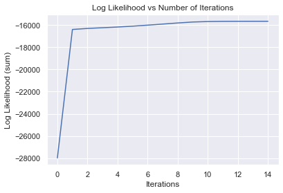

```python
# EM-GMM for digit data
# number of digit classes
K = 2

# random seed
seed = 42

# initialize prior
# np.random.seed(seed)
pi = np.random.random(K)
pi = pi/np.sum(pi)

# initial mean and covariance
# np.random.seed(seed)
mu = np.random.randn(K,4)
mu_old = mu.copy()

sigma = []
for ii in range(K):
    # to ensure the covariance psd
    # np.random.seed(seed)
    dummy = np.random.randn(4, 4)
    sigma.append(dummy@dummy.T+np.eye(4))

# initialize the posterior
tau = np.full((m, K), fill_value=0.)

# initialize the likelihood
llh = np.full((m, K), fill_value=0.)

# # parameter for countour plot
# xrange = np.arange(-5, -5, 0.1)
# yrange = np.arange(-5, -5, 0.1)

# ####
maxIter= 100
tol = 1e-2

plt.ion()

log_like = []
iterations = []

for ii in range(100):

    # E-step
    for kk in range(K):
        tau[:, kk] = pi[kk] * mvn.pdf(x_proj, mu[kk], sigma[kk])

        llh[:, kk] = pi[kk] * mvn.pdf(x_proj, mu[kk], sigma[kk])

    # normalize tau
    sum_tau = np.sum(tau, axis=1)
    sum_tau.shape = (m,1)
    tau = np.divide(tau, np.tile(sum_tau, (1, K)))


    # M-step
    for kk in range(K):
        # update prior
        pi[kk] = np.sum(tau[:, kk])/m

        # update component mean
        mu[kk] = x_proj.T @ tau[:,kk] / np.sum(tau[:,kk], axis = 0)

        # update cov matrix
        dummy = x_proj - np.tile(mu[kk], (m,1)) # X-mu
        sigma[kk] = dummy.T @ np.diag(tau[:,kk]) @ dummy / np.sum(tau[:,kk], axis = 0)

    #print('-----iteration---',ii)
    #print('Log-Likelihood (sum):',np.sum(np.log(np.sum(llh,axis=1))))

    log_like.append(np.sum(np.log(np.sum(llh,axis=1))))
    iterations.append(ii)

    if np.linalg.norm(mu-mu_old) < tol:
        print('training coverged')
        break
    mu_old = mu.copy()
    if ii==99:
        print('max iteration reached')
        break

plt.plot(iterations, log_like)
plt.title("Log Likelihood vs Number of Iterations")
plt.ylabel('Log Likelihood (sum)')
plt.xlabel('Iterations')
plt.show()
```

### 2 (c): Report the fitted GMM model

posterior means of each latent Gaussian

```python
mu
```

```
array([[-6.86628478,  1.98684347,  0.06967933, -0.47731838],
       [-6.99692044, -2.19471701, -0.08265557,  0.31252929]])
```

posterior weights

```python
pi
```

```
array([0.51227004, 0.48772996])
```

posterior covariance matrix

```python
sigma
```

```
[array([[ 3.18358838, -1.32203456, -0.32780244, -0.29635426],
        [-1.32203456,  1.69363236,  0.34336186,  0.39520337],
        [-0.32780244,  0.34336186,  5.87158552,  1.93867412],
        [-0.29635426,  0.39520337,  1.93867412,  2.31983833]]),
 array([[ 2.97073272,  0.36093295,  0.26847198, -0.94429828],
        [ 0.36093295,  1.5566962 , -0.68745127,  1.26689877],
        [ 0.26847198, -0.68745127,  1.78470381, -1.97545337],
        [-0.94429828,  1.26689877, -1.97545337,  4.77066693]])]
```

First average image

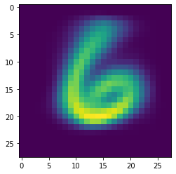

```python
# adapted from:
 # https://stackoverflow.com/questions/2659312/
    # how-do-i-convert-a-numpy-array-to-and-display-an-image

Gaussian_1 = (V.dot(mu[0])+np.mean(x)).reshape((28,28))

from matplotlib import pyplot as plt
plt.imshow(Gaussian_1.T, interpolation='nearest')
plt.show()
```

First covariance matrix as a heatmap

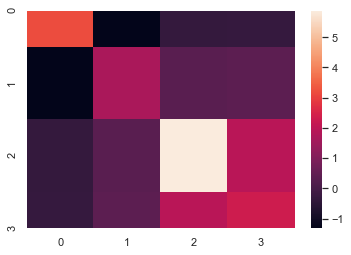

```python
sns.set_theme()

ax = sns.heatmap(sigma[0])
```

Second average image

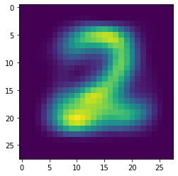

```python
Gaussian_2 = (V.dot(mu[1])+np.mean(x)).reshape((28,28))

from matplotlib import pyplot as plt
plt.imshow(Gaussian_2.T, interpolation='nearest')
plt.show()
```

Second covariance matrix as a heatmap

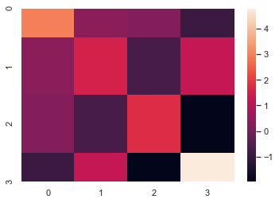

```python
ax = sns.heatmap(sigma[1])
```

### 2 (d): Infer the labels of the images

```python
# inferred labels from tau
GMM_labels = np.where(np.argmax(tau, axis=1) == 1, 2, 6)
GMM_labels
```

```
array([2, 2, 2, ..., 6, 6, 6])
```

```python
# true labels
y[0]
```

[output not shown]

#### $\tau_k^i$ mis-classification rate for digit "2"

```python
# adapted from: https://stackoverflow.com/questions/20402109/
                    # calculating-percentage-error-by-comparing-two-arrays/20402224
ind_2 = np.where(GMM_labels == 2)

# False Positive rate (Type I error)
misclassification_rate = np.mean(GMM_labels[ind_2] != y[0][ind_2])
print("Mis-classification rate for '2' = {}%".format(round(misclassification_rate*100,3)))
```

```
Mis-classification rate for '2' = 0.923%
```

#### $\tau_k^i$ mis-classification rate for digit "6"

```python
ind_6 = np.where(GMM_labels == 6)

# False Positive rate (Type I error)
misclassification_rate = np.mean(GMM_labels[ind_6] != y[0][ind_6])
print("Mis-classification rate for '6' = {}%".format(round(misclassification_rate*100,3)))
```

```
Mis-classification rate for '6' = 6.502%
```

### K-means clustering with K=2

```python
# run k-means clustering
kmeans = KMeans(n_clusters=2, random_state=0).fit(x)
```

```python
kmeans_labels = np.where(kmeans.labels_ == 1, 2, 6)
kmeans_labels
```

```
array([2, 2, 2, ..., 2, 6, 6])
```

#### K-means mis-classification rate for digit "2"

```python
# adapted from: https://stackoverflow.com/questions/20402109/
                    # calculating-percentage-error-by-comparing-two-arrays/20402224
ind_2_km = np.where(kmeans_labels == 2)

# False Positive rate (Type I error)
misclassification_rate = np.mean(kmeans_labels[ind_2_km] != y[0][ind_2_km])
print("Mis-classification rate for '2' = {}%".format(round(misclassification_rate*100,3)))
```

```
Mis-classification rate for '2' = 6.513%
```

#### K-means mis-classification rate for digit "6"

```python
# adapted from: https://stackoverflow.com/questions/20402109/
                    # calculating-percentage-error-by-comparing-two-arrays/20402224
ind_6_km = np.where(kmeans_labels == 6)

# False Positive rate (Type I error)
misclassification_rate = np.mean(kmeans_labels[ind_6_km] != y[0][ind_6_km])
print("Mis-classification rate for '6' = {}%".format(round(misclassification_rate*100,3)))
```

```
Mis-classification rate for '6' = 5.92%
```

#### Overall

```python
misclassification_rate = np.mean(GMM_labels != y[0])
print("Overall mis-classification rate for GMM = {}%".format(round(misclassification_rate*100,3)))

misclassification_rate = np.mean(kmeans_labels != y[0])
print("Overall mis-classification rate for K-means = {}%".format(round(misclassification_rate*100,3)))
```

```
Overall mis-classification rate for GMM = 3.769%
Overall mis-classification rate for K-means = 6.231%
```

#### Performance Comparison

When classifying the digit "2", GMM had a mis-classification rate of 0.9%, whereas K-means had a mis-classification rate of 6.5%. From these results, we can conclude that GMM achieved better performance than K-means when classifying the digit "2".

When classifying the digit "6", GMM had a mis-classification rate of 6.5%, whereas K-means had a mis-classification rate of 5.9%. From these results, we can conclude that K-means achieved better performance than GMM when classifying the digit "6".

Overall, when looking at total mis-classification rate, GMM outperforms K-means with a mis-classification rate of 3.8% versus 6.2%, respectively.